# ExploratoryDataAnalysis-SuperStore

```python
import pandas as pd
import numpy as np
import matplotlib.pyplot as plt
import seaborn as sns
#importing Important libraries
```

```python
storeData = pd.read_csv("SampleSuperstore.csv")
storeData
#reading data
```

|  | Ship Mode | Segment | Country | City | State | Postal Code | Region | Category | Sub-Category | Sales | Quantity | Discount | Profit |
| --- | --- | --- | --- | --- | --- | --- | --- | --- | --- | --- | --- | --- | --- |
| 0 | Second Class | Consumer | United States | Henderson | Kentucky | 42420 | South | Furniture | Bookcases | 261.9600 | 2 | 0.00 | 41.9136 |
| 1 | Second Class | Consumer | United States | Henderson | Kentucky | 42420 | South | Furniture | Chairs | 731.9400 | 3 | 0.00 | 219.5820 |
| 2 | Second Class | Corporate | United States | Los Angeles | California | 90036 | West | Office Supplies | Labels | 14.6200 | 2 | 0.00 | 6.8714 |
| 3 | Standard Class | Consumer | United States | Fort Lauderdale | Florida | 33311 | South | Furniture | Tables | 957.5775 | 5 | 0.45 | -383.0310 |
| 4 | Standard Class | Consumer | United States | Fort Lauderdale | Florida | 33311 | South | Office Supplies | Storage | 22.3680 | 2 | 0.20 | 2.5164 |
| ... | ... | ... | ... | ... | ... | ... | ... | ... | ... | ... | ... | ... | ... |
| 9989 | Second Class | Consumer | United States | Miami | Florida | 33180 | South | Furniture | Furnishings | 25.2480 | 3 | 0.20 | 4.1028 |
| 9990 | Standard Class | Consumer | United States | Costa Mesa | California | 92627 | West | Furniture | Furnishings | 91.9600 | 2 | 0.00 | 15.6332 |
| 9991 | Standard Class | Consumer | United States | Costa Mesa | California | 92627 | West | Technology | Phones | 258.5760 | 2 | 0.20 | 19.3932 |
| 9992 | Standard Class | Consumer | United States | Costa Mesa | California | 92627 | West | Office Supplies | Paper | 29.6000 | 4 | 0.00 | 13.3200 |
| 9993 | Second Class | Consumer | United States | Westminster | California | 92683 | West | Office Supplies | Appliances | 243.1600 | 2 | 0.00 | 72.9480 |

9994 rows × 13 columns

```python
storeData.head(10)
```

|  | Ship Mode | Segment | Country | City | State | Postal Code | Region | Category | Sub-Category | Sales | Quantity | Discount | Profit |
| --- | --- | --- | --- | --- | --- | --- | --- | --- | --- | --- | --- | --- | --- |
| 0 | Second Class | Consumer | United States | Henderson | Kentucky | 42420 | South | Furniture | Bookcases | 261.9600 | 2 | 0.00 | 41.9136 |
| 1 | Second Class | Consumer | United States | Henderson | Kentucky | 42420 | South | Furniture | Chairs | 731.9400 | 3 | 0.00 | 219.5820 |
| 2 | Second Class | Corporate | United States | Los Angeles | California | 90036 | West | Office Supplies | Labels | 14.6200 | 2 | 0.00 | 6.8714 |
| 3 | Standard Class | Consumer | United States | Fort Lauderdale | Florida | 33311 | South | Furniture | Tables | 957.5775 | 5 | 0.45 | -383.0310 |
| 4 | Standard Class | Consumer | United States | Fort Lauderdale | Florida | 33311 | South | Office Supplies | Storage | 22.3680 | 2 | 0.20 | 2.5164 |
| 5 | Standard Class | Consumer | United States | Los Angeles | California | 90032 | West | Furniture | Furnishings | 48.8600 | 7 | 0.00 | 14.1694 |
| 6 | Standard Class | Consumer | United States | Los Angeles | California | 90032 | West | Office Supplies | Art | 7.2800 | 4 | 0.00 | 1.9656 |
| 7 | Standard Class | Consumer | United States | Los Angeles | California | 90032 | West | Technology | Phones | 907.1520 | 6 | 0.20 | 90.7152 |
| 8 | Standard Class | Consumer | United States | Los Angeles | California | 90032 | West | Office Supplies | Binders | 18.5040 | 3 | 0.20 | 5.7825 |
| 9 | Standard Class | Consumer | United States | Los Angeles | California | 90032 | West | Office Supplies | Appliances | 114.9000 | 5 | 0.00 | 34.4700 |

```python
storeData.isnull().sum()
```

```
Ship Mode       0
Segment         0
Country         0
City            0
State           0
Postal Code     0
Region          0
Category        0
Sub-Category    0
Sales           0
Quantity        0
Discount        0
Profit          0
dtype: int64
```

```python
storeData.info()
```

```
<class 'pandas.core.frame.DataFrame'>
RangeIndex: 9994 entries, 0 to 9993
Data columns (total 13 columns):
 #   Column        Non-Null Count  Dtype
---  ------        --------------  -----
 0   Ship Mode     9994 non-null   object
 1   Segment       9994 non-null   object
 2   Country       9994 non-null   object
 3   City          9994 non-null   object
 4   State         9994 non-null   object
 5   Postal Code   9994 non-null   int64
 6   Region        9994 non-null   object
 7   Category      9994 non-null   object
 8   Sub-Category  9994 non-null   object
 9   Sales         9994 non-null   float64
 10  Quantity      9994 non-null   int64
 11  Discount      9994 non-null   float64
 12  Profit        9994 non-null   float64
dtypes: float64(3), int64(2), object(8)
memory usage: 1015.1+ KB
```

```python
storeData.describe()
```

|  | Postal Code | Sales | Quantity | Discount | Profit |
| --- | --- | --- | --- | --- | --- |
| count | 9994.000000 | 9994.000000 | 9994.000000 | 9994.000000 | 9994.000000 |
| mean | 55190.379428 | 229.858001 | 3.789574 | 0.156203 | 28.656896 |
| std | 32063.693350 | 623.245101 | 2.225110 | 0.206452 | 234.260108 |
| min | 1040.000000 | 0.444000 | 1.000000 | 0.000000 | -6599.978000 |
| 25% | 23223.000000 | 17.280000 | 2.000000 | 0.000000 | 1.728750 |
| 50% | 56430.500000 | 54.490000 | 3.000000 | 0.200000 | 8.666500 |
| 75% | 90008.000000 | 209.940000 | 5.000000 | 0.200000 | 29.364000 |
| max | 99301.000000 | 22638.480000 | 14.000000 | 0.800000 | 8399.976000 |

```python
storeData.duplicated().sum()
```

```
17
```

```python
storeData.columns
```

```
Index(['Ship Mode', 'Segment', 'Country', 'City', 'State', 'Postal Code',
       'Region', 'Category', 'Sub-Category', 'Sales', 'Quantity', 'Discount',
       'Profit'],
      dtype='object')
```

```python
storeData.drop_duplicates(subset=None, keep='first', inplace=True)
storeData
```

|  | Ship Mode | Segment | Country | City | State | Postal Code | Region | Category | Sub-Category | Sales | Quantity | Discount | Profit |
| --- | --- | --- | --- | --- | --- | --- | --- | --- | --- | --- | --- | --- | --- |
| 0 | Second Class | Consumer | United States | Henderson | Kentucky | 42420 | South | Furniture | Bookcases | 261.9600 | 2 | 0.00 | 41.9136 |
| 1 | Second Class | Consumer | United States | Henderson | Kentucky | 42420 | South | Furniture | Chairs | 731.9400 | 3 | 0.00 | 219.5820 |
| 2 | Second Class | Corporate | United States | Los Angeles | California | 90036 | West | Office Supplies | Labels | 14.6200 | 2 | 0.00 | 6.8714 |
| 3 | Standard Class | Consumer | United States | Fort Lauderdale | Florida | 33311 | South | Furniture | Tables | 957.5775 | 5 | 0.45 | -383.0310 |
| 4 | Standard Class | Consumer | United States | Fort Lauderdale | Florida | 33311 | South | Office Supplies | Storage | 22.3680 | 2 | 0.20 | 2.5164 |
| ... | ... | ... | ... | ... | ... | ... | ... | ... | ... | ... | ... | ... | ... |
| 9989 | Second Class | Consumer | United States | Miami | Florida | 33180 | South | Furniture | Furnishings | 25.2480 | 3 | 0.20 | 4.1028 |
| 9990 | Standard Class | Consumer | United States | Costa Mesa | California | 92627 | West | Furniture | Furnishings | 91.9600 | 2 | 0.00 | 15.6332 |
| 9991 | Standard Class | Consumer | United States | Costa Mesa | California | 92627 | West | Technology | Phones | 258.5760 | 2 | 0.20 | 19.3932 |
| 9992 | Standard Class | Consumer | United States | Costa Mesa | California | 92627 | West | Office Supplies | Paper | 29.6000 | 4 | 0.00 | 13.3200 |
| 9993 | Second Class | Consumer | United States | Westminster | California | 92683 | West | Office Supplies | Appliances | 243.1600 | 2 | 0.00 | 72.9480 |

9977 rows × 13 columns

# Exploratory Data Analysis

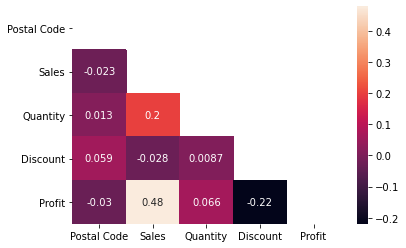

```python
matrix = np.triu(storeData.corr())
sns.heatmap(storeData.corr(), annot=True, mask=matrix)
```

# Univariate Analysis

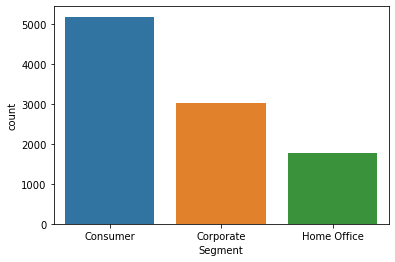

```python
sns.countplot(x=storeData['Segment'])
```

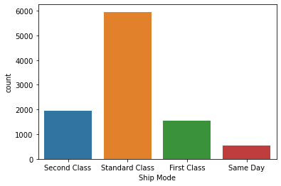

```python
sns.countplot(x=storeData['Ship Mode'])
```

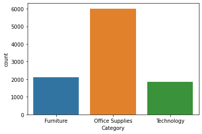

```python
sns.countplot(x=storeData['Category'])
```

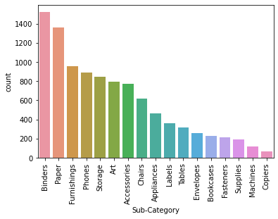

```python
sns.countplot(x=storeData['Sub-Category'], order=(storeData['Sub-Category'].value_counts().head(20)).index)
plt.xticks(rotation=90)
```

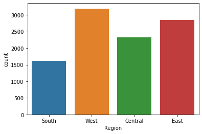

```python
sns.countplot(x=storeData['Region'])
```

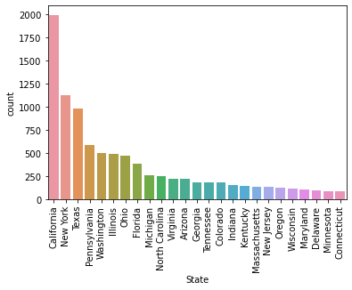

```python
sns.countplot(x=storeData['State'],order=(storeData['State'].value_counts().head(25)).index)
plt.xticks(rotation=90)
```

# Bivariate Analysis

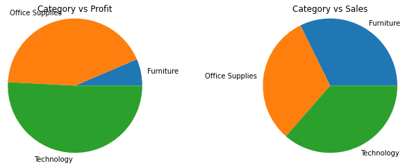

```python
#Pie chart : Category vs Profit and Sales
data=storeData[['Category','Profit','Sales']]
data=data.set_index('Category')
data=data.groupby(level=0).sum()
sale=list(data['Sales'])
prof=list(data['Profit'])
ind=data.index.values.tolist()

fig = plt.figure()

ax1 = fig.add_axes([.7, .0, .8, .7], aspect=1)
ax1.pie(sale, labels=ind, radius = 1.2)
ax2 = fig.add_axes([0, 0, .5, 0.7], aspect=1)
ax2.pie(prof, labels=ind, radius = 1.2)
ax1.set_title('Category vs Sales')
ax2.set_title('Category vs Profit')
plt.show()
```

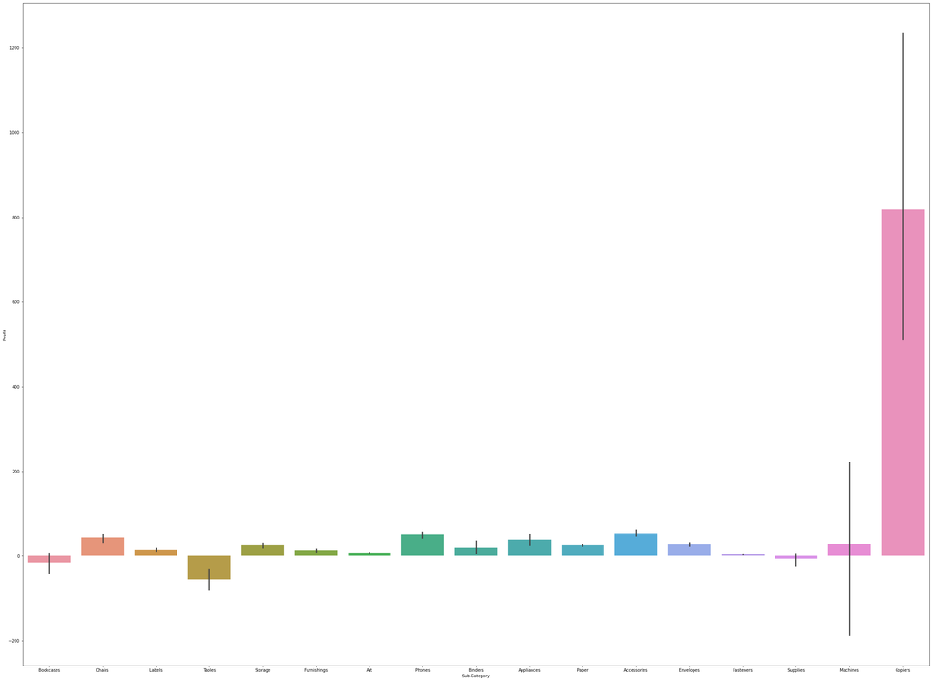

```python
%matplotlib inline
plt.figure(figsize=(40,30))
sns.barplot(x=storeData['Sub-Category'], y=storeData['Profit'])
```

# Preliminary takeaways from the analysis

Using the above plots, we can infer that the store is actually bearing a loss in selling bookcases and tables. However, the sales of the two products is pretty good.

The store earns holds a good profit margin in the sale of copiers but the sale quantity of the copier is low.

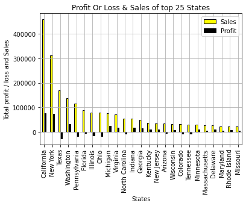

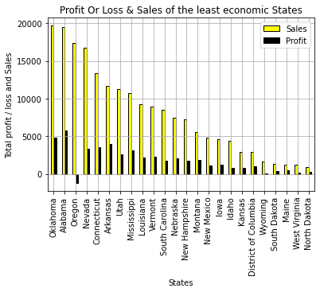

```python
state = storeData.groupby("State")[["Sales","Profit"]].sum().sort_values(by = "Sales", ascending = False)
plt.figure(figsize = (20,20))
state[:25].plot(kind = "bar",color = ["yellow","k"],edgecolor = "#000000")
plt.title("Profit Or Loss & Sales of top 25 States")
plt.xlabel("States")
plt.ylabel("Total profit / loss and Sales")
plt.grid(True)
state[25:].plot(kind = "bar",color = ["yellow","k"],edgecolor = "#000000")
plt.title("Profit Or Loss & Sales of the least economic States")
plt.xlabel("States")
plt.ylabel("Total profit / loss and Sales")
plt.grid(True)
```

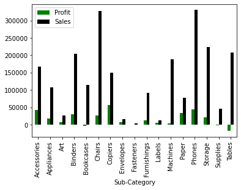

```python
storeData.groupby('Sub-Category')['Profit','Sales'].sum().plot.bar(color = ['g','k'])
```

```python
pd.DataFrame(storeData.groupby('State').sum())['Profit'].sort_values(ascending=True)
```

```
State
Texas                  -25750.9833
Ohio                   -16959.3178
Pennsylvania           -15565.4035
Illinois               -12601.6500
North Carolina          -7490.9122
Colorado                -6527.8579
Tennessee               -5341.6936
Arizona                 -3427.9246
Florida                 -3399.3017
Oregon                  -1194.0993
Wyoming                   100.1960
West Virginia             185.9216
North Dakota              230.1497
South Dakota              394.8283
Maine                     454.4862
Idaho                     826.7231
Kansas                    836.4435
District of Columbia     1059.5893
New Mexico               1157.1161
Iowa                     1183.8119
New Hampshire            1706.5028
South Carolina           1769.0566
Montana                  1833.3285
Nebraska                 2037.0942
Louisiana                2196.1023
Vermont                  2244.9783
Utah                     2546.5335
Mississippi              3172.9762
Nevada                   3316.7659
Connecticut              3511.4918
Arkansas                 4008.6871
Oklahoma                 4853.9560
Alabama                  5786.8253
Missouri                 6436.2105
Massachusetts            6785.5016
Maryland                 7031.1788
Rhode Island             7285.6293
Wisconsin                8401.8004
New Jersey               9772.9138
Delaware                 9977.3748
Minnesota               10823.1874
Kentucky                11199.6966
Georgia                 16250.0433
Indiana                 18382.9363
Virginia                18597.9504
Michigan                24428.0903
Washington              33368.2375
New York                74015.4622
California              76330.7891
Name: Profit, dtype: float64
```

```python
pd.DataFrame(storeData.groupby('State').sum())['Discount'].sort_values(ascending=True)
```

```
State
Alabama                   0.00
Missouri                  0.00
Maine                     0.00
Louisiana                 0.00
Kentucky                  0.00
Kansas                    0.00
Iowa                      0.00
Indiana                   0.00
Wisconsin                 0.00
Mississippi               0.00
Nebraska                  0.00
North Dakota              0.00
District of Columbia      0.00
Oklahoma                  0.00
South Carolina            0.00
South Dakota              0.00
Vermont                   0.00
Arkansas                  0.00
Virginia                  0.00
Georgia                   0.00
Minnesota                 0.00
Wyoming                   0.20
West Virginia             0.30
New Hampshire             0.30
Maryland                  0.60
Connecticut               0.60
New Jersey                0.60
Delaware                  0.60
Montana                   1.00
Rhode Island              1.20
Idaho                     1.80
Michigan                  1.80
Massachusetts             2.10
New Mexico                2.20
Nevada                    2.40
Utah                      3.20
Washington               32.40
Oregon                   35.60
Tennessee                53.30
Colorado                 57.60
New York                 62.40
Arizona                  68.00
North Carolina           70.60
Florida                 114.65
California              145.60
Ohio                    152.10
Illinois                191.10
Pennsylvania            192.70
Texas                   364.24
Name: Discount, dtype: float64
```

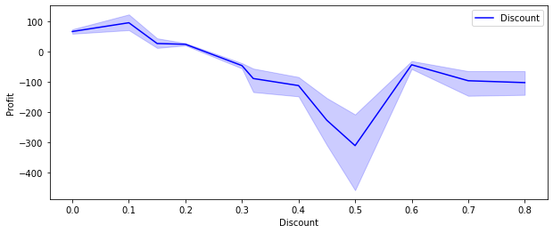

```python
plt.figure(figsize = (10,4))
sns.lineplot('Discount', 'Profit', data = storeData, color = 'b', label= 'Discount')
plt.legend()
```

# Insights derived from the above EDA:

Discounts and Profits shows a kind of inverse relation. Thus, the store management should levy discounts carefully and smartly.

The store is actually bearing a loss in selling bookcases and tables. However, the sales of the two products is pretty good. This can be used advantaegously to earn profits or minimize the losses.

The store earns holds a good profit margin in the sale of copiers but the sale quantity of the copier is low. Thus, in order to increase the net profits the sale should increase this could be done by providing small discounts or introducing attractive offers.